# Homework 2

Anthony Zhang - SDS 313 UT Austin

2024-09-20

# **Introduction**

I am investigating the prevalance of leprosy in different countries and regions all around the world. Also, I am seeing if there is a relationship between the leprosy cases per 100k people and the GDB in billions.

# **1. Question 1**

**Which country had the highest number of new leprosy cases in 2022? Why is it not a fair comparison to look at the raw number of cases when comparing prevalence of the disease across different countries?**

The country that had the highest number of new leprosy cases in 2022 is India. It is not a fair comparison to look at the raw number of cases when comparing prevalence of the disease across different countries because different countries have different populations. It is expected for a country with a higher population to have a higher raw number of cases. Instead, comparing the prevalence rate or the proportion of the new cases / the population is a better indicator of prevalence of disease in that country since it accounts for the population too. Essentially, 100 people getting leprosy in a small country is a bigger deal than 100 people getting leprosy in a country with a high population.

```r
#reading files
leprosy <- read.csv('Homework2_leprosy.csv')
# which row number had the most cases total
# which gives the row number for the condition
x <- leprosy$New_Cases
y <- max(leprosy$New_Cases, na.rm = TRUE)
z <- which(x == y)
leprosy[z,]
```

```
##    Country Code       Region Population GDP_billions Land_Area New_Cases
## 76   India  IND Asia/Pacific 1399179585     3176.295   1147955    103819
```

```r
#make subset which is clean without the NA values
leprosy_clean <- na.omit(leprosy)

#making a new column for the diease prevalance rate
leprosy_clean$proportion <- (leprosy_clean[,"New_Cases"] / leprosy_clean[, "Population"]) * 100

#putting countries data in 1st column and prevalance rate data in second column
countries <- c(leprosy_clean$Country)
proportion <- c(leprosy_clean$proportion)
leprosy_proportion <- data.frame(Country = countries, Proportion = proportion)

#setting column names
colnames(leprosy_proportion) <- c('Country','Proportion')
leprosy_proportion$Proportion<- round(leprosy_proportion$Proportion, 2)


#Output table:
kable_classic(kbl(leprosy_proportion,caption = "Leprosy Prevalance Rate"),full_width = FALSE)
```

Leprosy Prevalance Rate

| Country | Proportion |
| --- | --- |
| Afghanistan | 0.00 |
| Albania | 0.00 |
| Algeria | 0.00 |
| Andorra | 0.00 |
| Angola | 0.00 |
| Argentina | 0.00 |
| Armenia | 0.00 |
| Australia | 0.00 |
| Austria | 0.00 |
| Bahamas | 0.00 |
| Bahrain | 0.00 |
| Bangladesh | 0.00 |
| Barbados | 0.00 |
| Belgium | 0.00 |
| Belize | 0.00 |
| Benin | 0.00 |
| Bhutan | 0.00 |
| Bolivia (Plurinational State of) | 0.00 |
| Bosnia and Herzegovina | 0.00 |
| Botswana | 0.00 |
| Brazil | 0.01 |
| Brunei Darussalam | 0.00 |
| Bulgaria | 0.00 |
| Burkina Faso | 0.00 |
| Burundi | 0.00 |
| Cabo Verde | 0.00 |
| Cambodia | 0.00 |
| Cameroon | 0.00 |
| Central African Republic | 0.01 |
| Chad | 0.00 |

[output cut: 115 more lines]

The first table is a snippet of row 76 of the leprosy dataset. It shows what kind of data the country with the highest number of new leprosy cases in 2022 had. Here, we can see that it is in the region of Asia / Pacific, has a code of IND, has a population of 1399179585, has a GDP of 3176.295, has a land area of 1147955, and has a count of 103819 new cases.

This second table shows the prevalance rate of leprosy in all the countries. The prevalance rate is the amount of new cases divided by the population size.

# **2. Question 2**

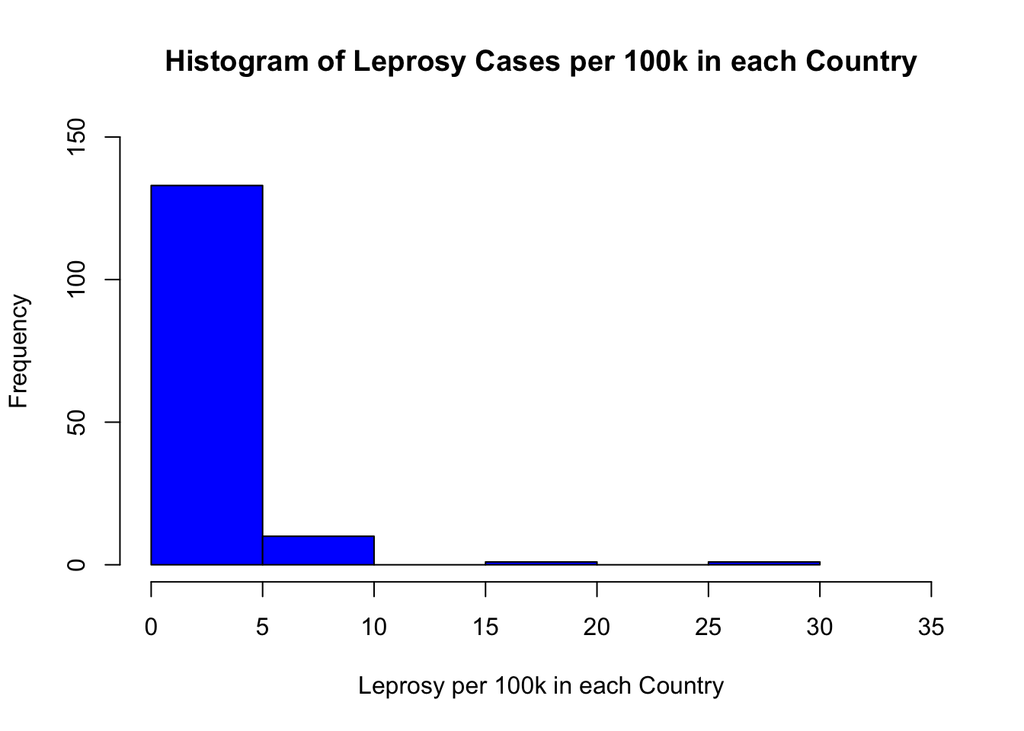

```r
#create a new column for a which is the leprosy cases per 100k people in each country
leprosy_clean$a <- (leprosy_clean$New_Cases / leprosy_clean$Population) * 100000

#create histogram of leprosy cases per 100k in each country
hist(leprosy_clean$a,main='Histogram of Leprosy Cases per 100k in each Country',xlab='Leprosy per 100k in each Country',ylab = 'Frequency',col='Blue',xlim=c(0,35), ylim = c(0,150))
```

```r
#get median of that column and round with 2 digits
round(median(leprosy_clean$a), digits=2)
```

```
## [1] 0.12
```

```r
round(fivenum(leprosy_clean$a), digits = 2)
```

```
## [1]  0.00  0.00  0.12  1.04 29.60
```

```r
round(IQR(leprosy_clean$a), digits = 2)
```

```
## [1] 1.04
```

# **3. Question 3**

**We want to compare cases per 100K across the different regions in this dataset. In a single plot output, create a graph that shows the distribution of cases per 100K split by region. Output a nicely formatted table that provides the region name, number of countries in that region, and the median cases per 100K for each region. Include a short paragraph summarizing differences in leprosy prevalence across regions.**

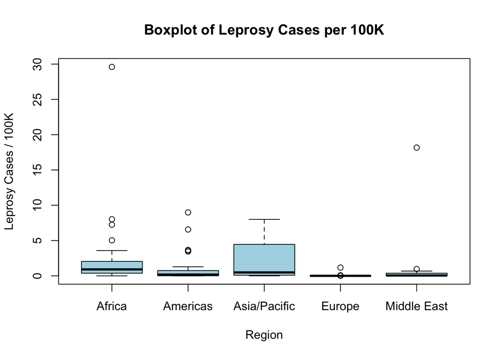

```r
# make a boxplot of region vs leprosy cases per 100k
boxplot(leprosy_clean$a ~ leprosy_clean$Region,
        main = "Boxplot of Leprosy Cases per 100K",
        xlab = "Region",
        ylab = "Leprosy Cases / 100K",
        col = "lightblue")
```

```r
#Create data frame of table:
mytable_count <- aggregate(Country ~ Region, data = leprosy_clean, length)
mytable_med <- aggregate(a~Region, data=leprosy_clean, median)

#merge those tables into one table
mytable <- merge(mytable_count, mytable_med, by = "Region")
#Rename columns and round values:
colnames(mytable) <- c('Region','Number of Countries','Median of Cases / 100k')
mytable$'Number of Countries' <- round(mytable$'Number of Countries', 2)
mytable$'Median of Cases / 100k' <- round(mytable$'Median of Cases / 100k', 2)

#Output table:
kable_classic(kbl(mytable,caption = "Number of Countries and Median of Cases / 100k"),full_width = FALSE)
```

Number of Countries and Median of Cases / 100k

| Region | Number of Countries | Median of Cases / 100k |
| --- | --- | --- |
| Africa | 38 | 0.91 |
| Americas | 28 | 0.17 |
| Asia/Pacific | 29 | 0.48 |
| Europe | 34 | 0.00 |
| Middle East | 16 | 0.05 |

The table shows the region, number of countries in that region, and the median of cases per 100k for that region. Africa had the most number of countries in that region while the Americas, Asia / Pacific, and Europe had around the same amount of countries in that region. Africa and Asia / Pacific had a significantly higher median of Cases per 100k people compared to the other regions. The Americas, Europe, and Middle East all had a relatively low median of cases per 100k people.

# **4. Question 4**

**Investigate the relationship between cases per 100K and one of the other variables in the dataset (other than region) by making the appropriate bivariate graph and providing the relevant summary statistic inline within a short paragraph describing the relationship.**

The leprosy cases per 100k people is not related to GDP in billions. There is a correlation coefficient of -0.02 between the cases per 100k people and the GDP in billions. Since this number is close to 0, there is no linear relationship between the two variables. Also, there is a negative relationship between the two variables because the correlation coefficient is negative.

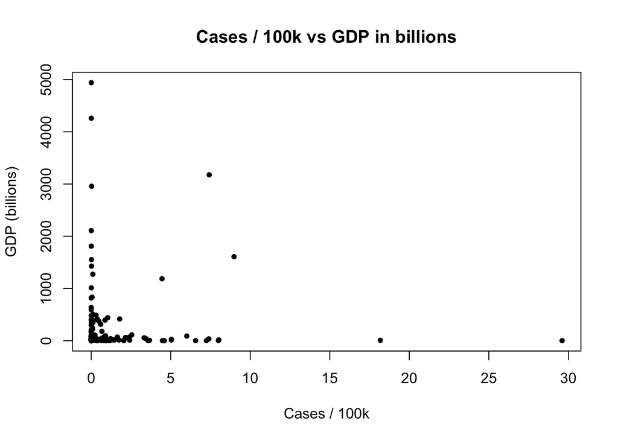

```r
plot(leprosy_clean$a,leprosy_clean$GDP_billions,main='Cases / 100k vs GDP in billions',xlab='Cases / 100k',ylab='GDP (billions)',pch=20)
```

```r
# find correlation coefficient which describes how correlated the two vars are
# around 0 for correlation coefficient means weak to no linear relationship between vars
round(cor(leprosy_clean$a,leprosy_clean$GDP_billions),digits = 2)
```

```
## [1] -0.02
```

This dot plot shows the relationship between leprosy cases per 100k people and GDP in billions. A lot of the points are in the bottom left corner meaning that most countries have low GDP and low leprosy cases per 100k. The points are pretty scattered meaning that there isn’t a strong relationship between the two variables.

# **5. Question 5**

[International Leprosy Association](https://www.leprosymission.org/about-us/global-fellowship/?gad_source=1&gclid=CjwKCAjwl6-3BhBWEiwApN6_koE3bAdKxwYvDy7U-4Mt60xAZntdpcfmyNZdwwqhKo-nnW2ZXVgVWRoC7m8QAvD_BwE)